# SAP PROJEKT - utjecaj glazbe na mentalno zdravlje

Marta Kekić, Erik Kranjec, Patricija Marijanović, Matija Martinović

2024-12-09

## Uvod

U sklopu ovog projekta analiziramo podatke iz ankete o glazbenim preferencijama, navikama slušanja i povezanosti s mentalnim zdravljem. Cilj je kroz zadatke istražiti obrasce i povezanosti unutar prikupljenih podataka.

Zadaci uključuju usporedbu navika slušanja između skladatelja i drugih ispitanika, analizu povezanosti žanrova s mentalnim zdravljem, istraživanje utjecaja streaming servisa na istraživanje nove glazbe, razlike u broju sati slušanja glazbe prema omiljenim žanrovima te ispitivanje mogućnosti predviđanja dobi ispitanika.

Ovaj projekt omogućuje nam praktičnu primjenu metoda analize podataka i dublje razumijevanje istraživačkog procesa.

## Učitavanje podataka, deskriptivna analiza

Učitavamo potrebne pakete.

```r
library(dplyr)
```

Učitavamo podatke.

```r
# učitavanje podataka iz csv datoteke:
dataset = read.csv("Music and mental health dataset.csv", sep = ",")

print("NA")
```

```
## [1] "NA"
```

```r
sum(is.na(dataset))  # Broji ukupan broj NA vrijednosti
```

```
## [1] 108
```

```r
# ispis prvih 6 redaka
head(dataset)
```

|  | Timestamp | Age | Primary.streaming.service | Hours.per.day | While.working | Instrumentalist | Composer | Fav.genre | Exploratory | Foreign.languages | BPM | Frequency..Classical. | Frequency..Country. | Frequency..EDM. | Frequency..Folk. | Frequency..Gospel. | Frequency..Hip.hop. | Frequency..Jazz. | Frequency..K.pop. | Frequency..Latin. | Frequency..Lofi. | Frequency..Metal. | Frequency..Pop. | Frequency..R.B. | Frequency..Rap. | Frequency..Rock. | Frequency..Video.game.music. | Anxiety | Depression | … |
| --- | --- | --- | --- | --- | --- | --- | --- | --- | --- | --- | --- | --- | --- | --- | --- | --- | --- | --- | --- | --- | --- | --- | --- | --- | --- | --- | --- | --- | --- | --- |
| 1 | 8/27/2022 19:29 | 18 | Spotify | 3.0 | Yes | Yes | Yes | Latin | Yes | Yes | 156 | Rarely | Never | Rarely | Never | Never | Sometimes | Never | Very frequently | Very frequently | Rarely | Never | Very frequently | Sometimes | Very frequently | Never | Sometimes | 3 | 0 | … |
| 2 | 8/27/2022 19:57 | 63 | Pandora | 1.5 | Yes | No | No | Rock | Yes | No | 119 | Sometimes | Never | Never | Rarely | Sometimes | Rarely | Very frequently | Rarely | Sometimes | Rarely | Never | Sometimes | Sometimes | Rarely | Very frequently | Rarely | 7 | 2 | … |
| 3 | 8/27/2022 21:28 | 18 | Spotify | 4.0 | No | No | No | Video game music | No | Yes | 132 | Never | Never | Very frequently | Never | Never | Rarely | Rarely | Very frequently | Never | Sometimes | Sometimes | Rarely | Never | Rarely | Rarely | Very frequently | 7 | 7 | … |
| 4 | 8/27/2022 21:40 | 61 | YouTube Music | 2.5 | Yes | No | Yes | Jazz | Yes | Yes | 84 | Sometimes | Never | Never | Rarely | Sometimes | Never | Very frequently | Sometimes | Very frequently | Sometimes | Never | Sometimes | Sometimes | Never | Never | Never | 9 | 7 | … |
| 5 | 8/27/2022 21:54 | 18 | Spotify | 4.0 | Yes | No | No | R&B | Yes | No | 107 | Never | Never | Rarely | Never | Rarely | Very frequently | Never | Very frequently | Sometimes | Sometimes | Never | Sometimes | Very frequently | Very frequently | Never | Rarely | 7 | 2 | … |
| 6 | 8/27/2022 21:56 | 18 | Spotify | 5.0 | Yes | Yes | Yes | Jazz | Yes | Yes | 86 | Rarely | Sometimes | Never | Never | Never | Sometimes | Very frequently | Very frequently | Rarely | Very frequently | Rarely | Very frequently | Very frequently | Very frequently | Very frequently | Never | 8 | 8 | … |

```r
dim(dataset)
```

```
## [1] 736  33
```

Podaci se sastoje od 736 redaka (odgovora) i 33 varijabli.

Ispitane varijable:

```r
names(dataset)
```

```
##  [1] "Timestamp"                    "Age"
##  [3] "Primary.streaming.service"    "Hours.per.day"
##  [5] "While.working"                "Instrumentalist"
##  [7] "Composer"                     "Fav.genre"
##  [9] "Exploratory"                  "Foreign.languages"
## [11] "BPM"                          "Frequency..Classical."
## [13] "Frequency..Country."          "Frequency..EDM."
## [15] "Frequency..Folk."             "Frequency..Gospel."
## [17] "Frequency..Hip.hop."          "Frequency..Jazz."
## [19] "Frequency..K.pop."            "Frequency..Latin."
## [21] "Frequency..Lofi."             "Frequency..Metal."
## [23] "Frequency..Pop."              "Frequency..R.B."
## [25] "Frequency..Rap."              "Frequency..Rock."
## [27] "Frequency..Video.game.music." "Anxiety"
## [29] "Depression"                   "Insomnia"
## [31] "OCD"                          "Music.effects"
## [33] "Permissions"
```

Ima li nedostajućih vrijednosti?

```r
# is.na ce nam vratiti logical vektor koji ima TRUE na mjestima gdje ima NA (tamo nedostaje vrijednost):
for (col_name in names(dataset)){
  if (sum(is.na(dataset[,col_name])) > 0){
    cat('Ukupno nedostajućih vrijednosti za varijablu ',col_name, ': ', sum(is.na(dataset[,col_name])),'\n')
  }
}
```

```
## Ukupno nedostajućih vrijednosti za varijablu  Age :  1
## Ukupno nedostajućih vrijednosti za varijablu  BPM :  107
```

Za stupac Age postoji jedna nedostajeća vrijednost, a za BPM 107. Svi ostali stupci su u potpunosti puni.

Deskriptivna statistika:

```r
summary(dataset)
```

```
##   Timestamp              Age        Primary.streaming.service Hours.per.day
##  Length:736         Min.   :10.00   Length:736                Min.   : 0.000
##  Class :character   1st Qu.:18.00   Class :character          1st Qu.: 2.000
##  Mode  :character   Median :21.00   Mode  :character          Median : 3.000
##                     Mean   :25.21                             Mean   : 3.573
##                     3rd Qu.:28.00                             3rd Qu.: 5.000
##                     Max.   :89.00                             Max.   :24.000
##                     NA's   :1
##  While.working      Instrumentalist      Composer          Fav.genre
##  Length:736         Length:736         Length:736         Length:736
##  Class :character   Class :character   Class :character   Class :character
##  Mode  :character   Mode  :character   Mode  :character   Mode  :character
##
##
##
##
##  Exploratory        Foreign.languages       BPM           Frequency..Classical.
##  Length:736         Length:736         Min.   :0.00e+00   Length:736
##  Class :character   Class :character   1st Qu.:1.00e+02   Class :character
##  Mode  :character   Mode  :character   Median :1.20e+02   Mode  :character
##                                        Mean   :1.59e+06
##                                        3rd Qu.:1.44e+02
##                                        Max.   :1.00e+09
##                                        NA's   :107
##  Frequency..Country. Frequency..EDM.    Frequency..Folk.   Frequency..Gospel.
##  Length:736          Length:736         Length:736         Length:736
##  Class :character    Class :character   Class :character   Class :character
##  Mode  :character    Mode  :character   Mode  :character   Mode  :character
##
##
##
##
##  Frequency..Hip.hop. Frequency..Jazz.   Frequency..K.pop.  Frequency..Latin.
##  Length:736          Length:736         Length:736         Length:736
##  Class :character    Class :character   Class :character   Class :character
##  Mode  :character    Mode  :character   Mode  :character   Mode  :character
##
##
##
##
```

[output cut: 17 more lines]

```
##  Min.   : 0.000   Min.   : 0.000   Min.   : 0.000   Min.   : 0.000
##  1st Qu.: 4.000   1st Qu.: 2.000   1st Qu.: 1.000   1st Qu.: 0.000
##  Median : 6.000   Median : 5.000   Median : 3.000   Median : 2.000
##  Mean   : 5.838   Mean   : 4.796   Mean   : 3.738   Mean   : 2.637
##  3rd Qu.: 8.000   3rd Qu.: 7.000   3rd Qu.: 6.000   3rd Qu.: 5.000
##  Max.   :10.000   Max.   :10.000   Max.   :10.000   Max.   :10.000
##
##  Music.effects      Permissions
##  Length:736         Length:736
##  Class :character   Class :character
##  Mode  :character   Mode  :character
##
##
##
##
```

Tipovi podataka za svaki stupac:

```r
sapply(dataset, class)
```

```
##                    Timestamp                          Age
##                  "character"                    "integer"
##    Primary.streaming.service                Hours.per.day
##                  "character"                    "numeric"
##                While.working              Instrumentalist
##                  "character"                  "character"
##                     Composer                    Fav.genre
##                  "character"                  "character"
##                  Exploratory            Foreign.languages
##                  "character"                  "character"
##                          BPM        Frequency..Classical.
##                    "integer"                  "character"
##          Frequency..Country.              Frequency..EDM.
##                  "character"                  "character"
##             Frequency..Folk.           Frequency..Gospel.
##                  "character"                  "character"
##          Frequency..Hip.hop.             Frequency..Jazz.
##                  "character"                  "character"
##            Frequency..K.pop.            Frequency..Latin.
##                  "character"                  "character"
##             Frequency..Lofi.            Frequency..Metal.
##                  "character"                  "character"
##              Frequency..Pop.              Frequency..R.B.
##                  "character"                  "character"
##              Frequency..Rap.             Frequency..Rock.
##                  "character"                  "character"
## Frequency..Video.game.music.                      Anxiety
##                  "character"                    "numeric"
##                   Depression                     Insomnia
##                    "numeric"                    "numeric"
##                          OCD                Music.effects
##                    "numeric"                  "character"
##                  Permissions
##                  "character"
```

Većina stupaca je tipa “character”.

## Vizualizacija podataka

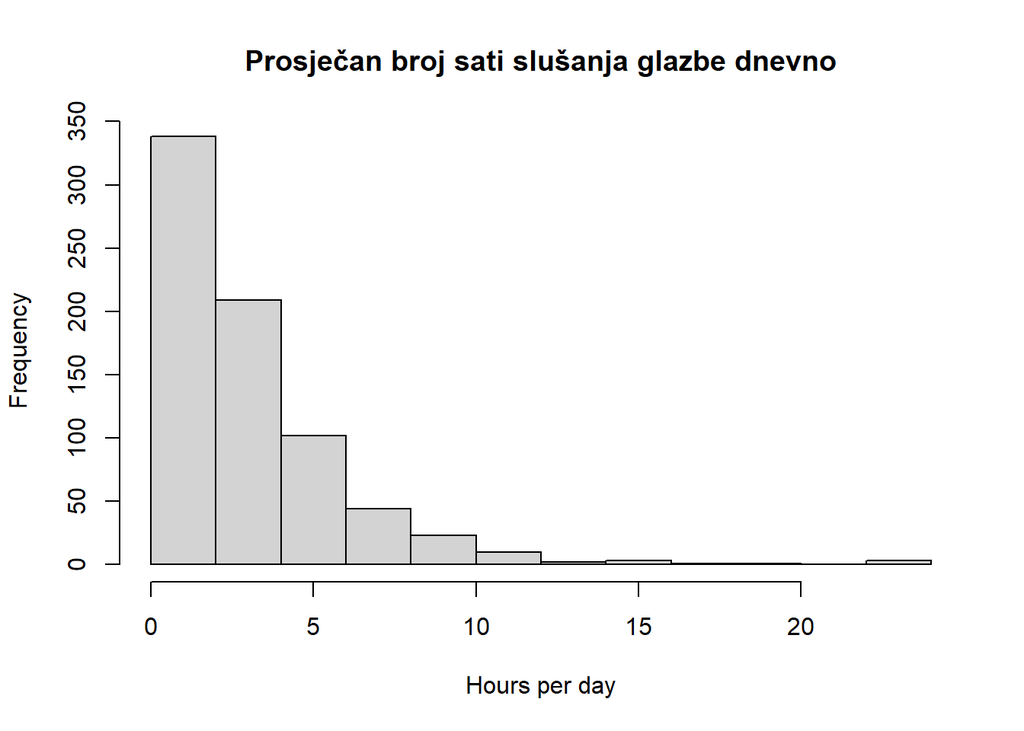

```r
hist(dataset$Hours.per.day, main='Prosječan broj sati slušanja glazbe dnevno', xlab='Hours per day', ylab='Frequency')
```

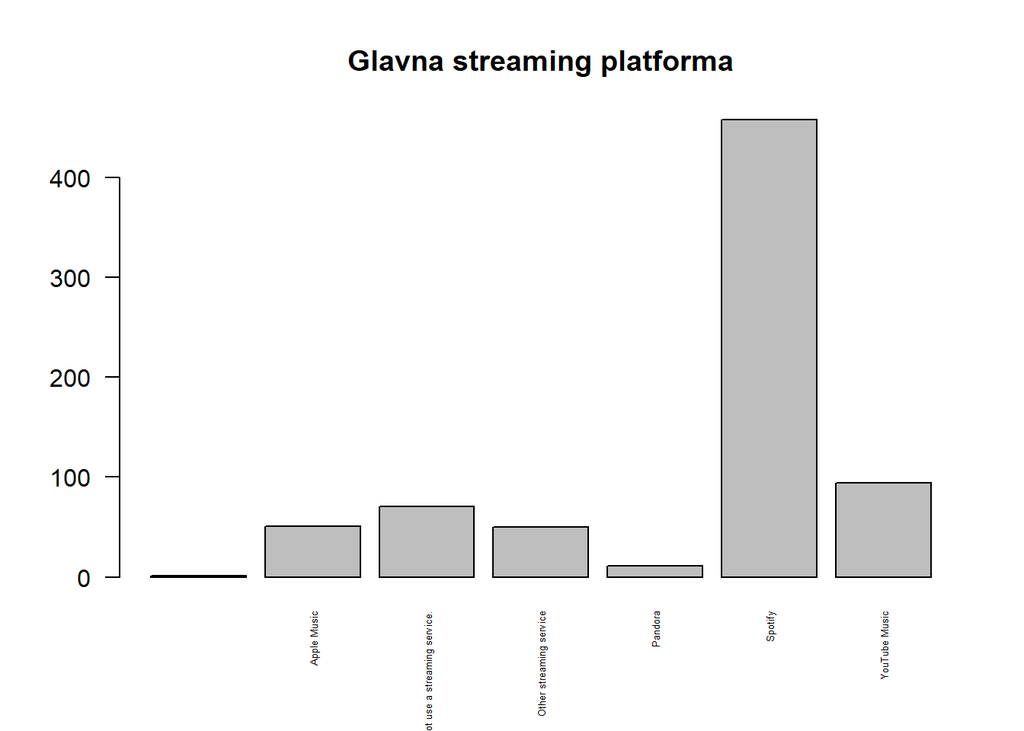

```r
barplot(table(dataset$Primary.streaming.service),las=2,cex.names=.4,main='Glavna streaming platforma')
```

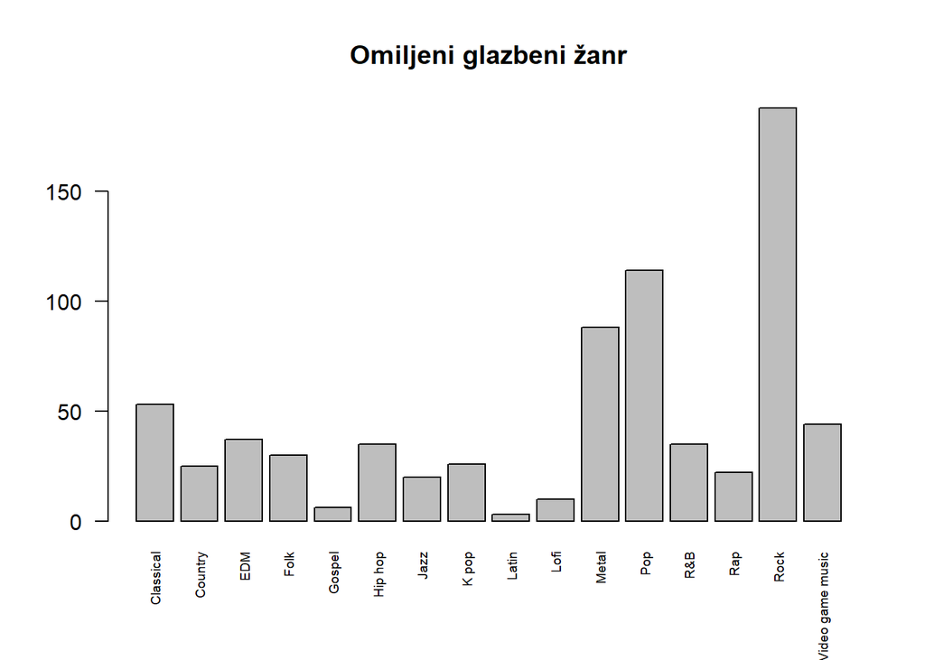

```r
barplot(table(dataset$Fav.genre),las=2,cex.names=.6,main='Omiljeni glazbeni žanr')
```

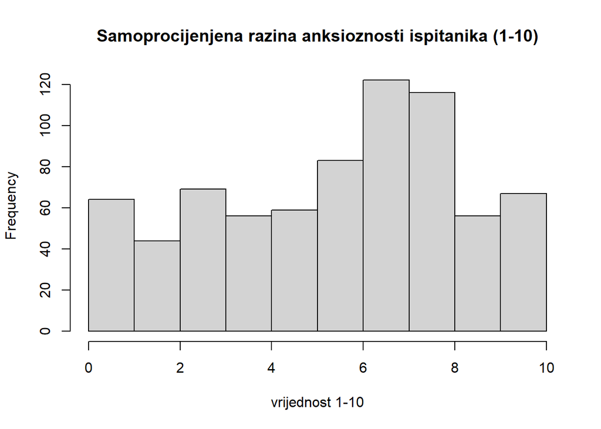

```r
hist(dataset$Anxiety, main='Samoprocijenjena razina anksioznosti ispitanika (1-10)', xlab='vrijednost 1-10', ylab='Frequency')
```

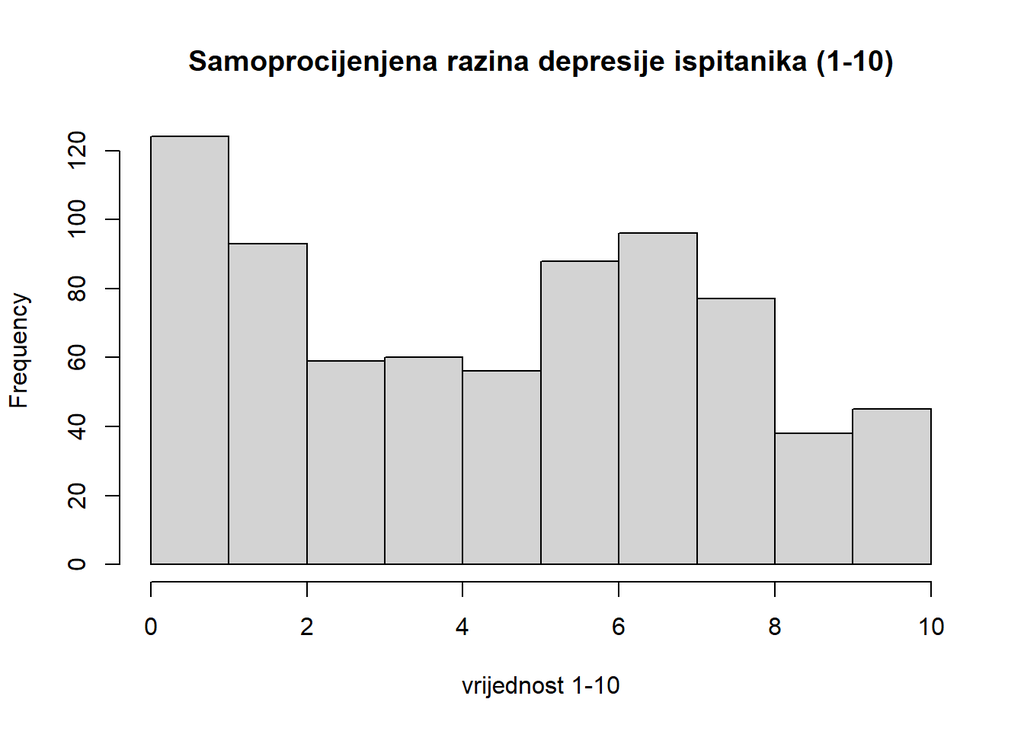

```r
hist(dataset$Depression, main='Samoprocijenjena razina depresije ispitanika (1-10)', xlab='vrijednost 1-10', ylab='Frequency')
```

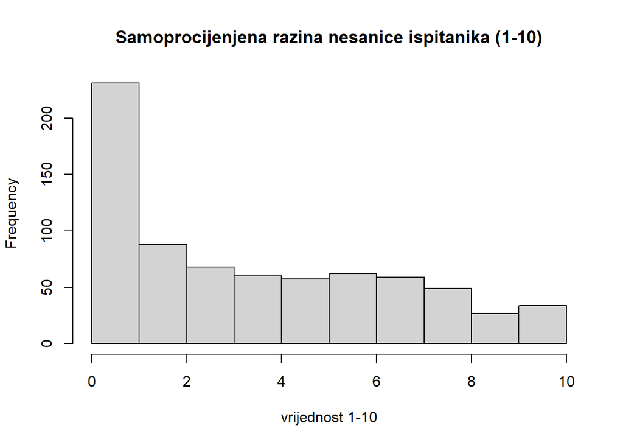

```r
hist(dataset$Insomnia, main='Samoprocijenjena razina nesanice ispitanika (1-10)', xlab='vrijednost 1-10', ylab='Frequency')
```

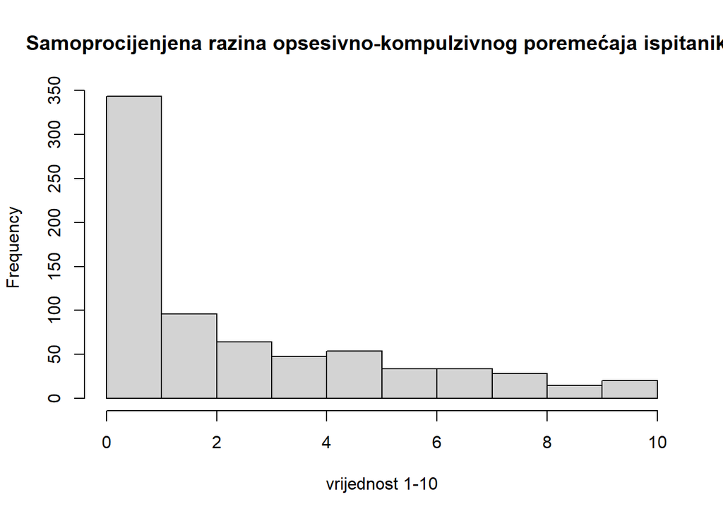

```r
hist(dataset$OCD, main='Samoprocijenjena razina opsesivno-kompulzivnog poremećaja ispitanika', xlab='vrijednost 1-10', ylab='Frequency')
```

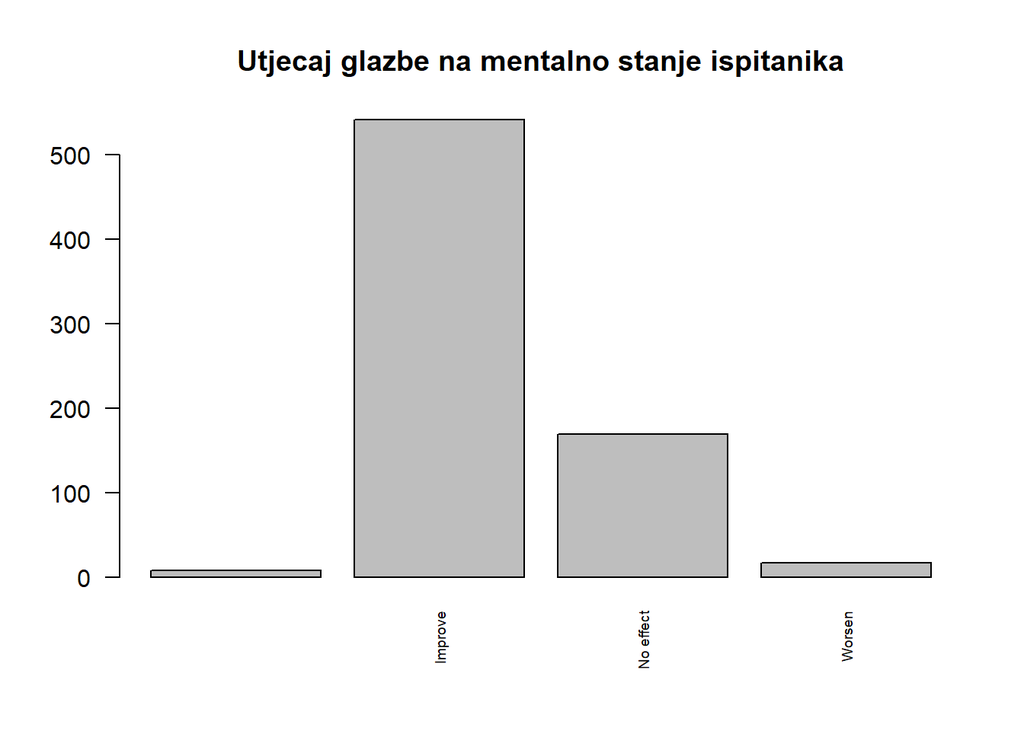

```r
barplot(table(dataset$Music.effects ),las=2,cex.names=.6,main='Utjecaj glazbe na mentalno stanje ispitanika')
```

## ZADATAK 1. - Slušaju li skladatelji više glazbe dnevno od drugih?

Koliko ima skladatelja:

```r
n1 <- sum(dataset$Composer == "Yes")
n2 <- sum(dataset$Composer == "No")

cat("skladatelja ima ", n1 ,"\n")
```

```
## skladatelja ima  126
```

```r
cat("ne-skladatelja ima ", n2 ,"\n")
```

```
## ne-skladatelja ima  609
```

Tablica koja sadrži samo skladatelje/ne-skladatelje:

```r
skladatelji = dataset[dataset$Composer == "Yes", ]
ne_skladatelji = dataset[dataset$Composer == "No", ]
head(skladatelji)
```

|  | Timestamp | Age | Primary.streaming.service | Hours.per.day | While.working | Instrumentalist | Composer | Fav.genre | Exploratory | Foreign.languages | BPM | Frequency..Classical. | Frequency..Country. | Frequency..EDM. | Frequency..Folk. | Frequency..Gospel. | Frequency..Hip.hop. | Frequency..Jazz. | Frequency..K.pop. | Frequency..Latin. | Frequency..Lofi. | Frequency..Metal. | Frequency..Pop. | Frequency..R.B. | Frequency..Rap. | Frequency..Rock. | Frequency..Video.game.music. | Anxiety | Depression | … |
| --- | --- | --- | --- | --- | --- | --- | --- | --- | --- | --- | --- | --- | --- | --- | --- | --- | --- | --- | --- | --- | --- | --- | --- | --- | --- | --- | --- | --- | --- | --- |
| 1 | 8/27/2022 19:29 | 18 | Spotify | 3.0 | Yes | Yes | Yes | Latin | Yes | Yes | 156 | Rarely | Never | Rarely | Never | Never | Sometimes | Never | Very frequently | Very frequently | Rarely | Never | Very frequently | Sometimes | Very frequently | Never | Sometimes | 3 | 0 | … |
| 4 | 8/27/2022 21:40 | 61 | YouTube Music | 2.5 | Yes | No | Yes | Jazz | Yes | Yes | 84 | Sometimes | Never | Never | Rarely | Sometimes | Never | Very frequently | Sometimes | Very frequently | Sometimes | Never | Sometimes | Sometimes | Never | Never | Never | 9 | 7 | … |
| 6 | 8/27/2022 21:56 | 18 | Spotify | 5.0 | Yes | Yes | Yes | Jazz | Yes | Yes | 86 | Rarely | Sometimes | Never | Never | Never | Sometimes | Very frequently | Very frequently | Rarely | Very frequently | Rarely | Very frequently | Very frequently | Very frequently | Very frequently | Never | 8 | 8 | … |
| 18 | 8/27/2022 23:39 | 16 | Spotify | 12.0 | Yes | No | Yes | Hip hop | Yes | Yes | 120 | Rarely | Never | Sometimes | Rarely | Never | Very frequently | Rarely | Never | Never | Never | Sometimes | Sometimes | Rarely | Sometimes | Very frequently | Never | 5 | 7 | … |
| 25 | 8/28/2022 4:13 | 16 | Other streaming service | 3.0 | Yes | Yes | Yes | Rock | Yes | Yes | 84 | Rarely | Rarely | Never | Rarely | Sometimes | Sometimes | Sometimes | Never | Rarely | Never | Sometimes | Never | Sometimes | Rarely | Very frequently | Sometimes | 10 | 6 | … |
| 27 | 8/28/2022 4:40 | 14 | Spotify | 12.0 | Yes | Yes | Yes | Rock | Yes | Yes | 136 | Sometimes | Sometimes | Rarely | Rarely | Rarely | Very frequently | Sometimes | Never | Never | Very frequently | Never | Very frequently | Very frequently | Very frequently | Very frequently | Sometimes | 8 | 6 | … |

```r
head(ne_skladatelji)
```

|  | Timestamp | Age | Primary.streaming.service | Hours.per.day | While.working | Instrumentalist | Composer | Fav.genre | Exploratory | Foreign.languages | BPM | Frequency..Classical. | Frequency..Country. | Frequency..EDM. | Frequency..Folk. | Frequency..Gospel. | Frequency..Hip.hop. | Frequency..Jazz. | Frequency..K.pop. | Frequency..Latin. | Frequency..Lofi. | Frequency..Metal. | Frequency..Pop. | Frequency..R.B. | Frequency..Rap. | Frequency..Rock. | Frequency..Video.game.music. | Anxiety | Depression | … |
| --- | --- | --- | --- | --- | --- | --- | --- | --- | --- | --- | --- | --- | --- | --- | --- | --- | --- | --- | --- | --- | --- | --- | --- | --- | --- | --- | --- | --- | --- | --- |
| 2 | 8/27/2022 19:57 | 63 | Pandora | 1.5 | Yes | No | No | Rock | Yes | No | 119 | Sometimes | Never | Never | Rarely | Sometimes | Rarely | Very frequently | Rarely | Sometimes | Rarely | Never | Sometimes | Sometimes | Rarely | Very frequently | Rarely | 7 | 2 | … |
| 3 | 8/27/2022 21:28 | 18 | Spotify | 4.0 | No | No | No | Video game music | No | Yes | 132 | Never | Never | Very frequently | Never | Never | Rarely | Rarely | Very frequently | Never | Sometimes | Sometimes | Rarely | Never | Rarely | Rarely | Very frequently | 7 | 7 | … |
| 5 | 8/27/2022 21:54 | 18 | Spotify | 4.0 | Yes | No | No | R&B | Yes | No | 107 | Never | Never | Rarely | Never | Rarely | Very frequently | Never | Very frequently | Sometimes | Sometimes | Never | Sometimes | Very frequently | Very frequently | Never | Rarely | 7 | 2 | … |
| 7 | 8/27/2022 22:00 | 18 | YouTube Music | 3.0 | Yes | Yes | No | Video game music | Yes | Yes | 66 | Sometimes | Never | Rarely | Sometimes | Rarely | Rarely | Sometimes | Never | Rarely | Rarely | Rarely | Rarely | Rarely | Never | Never | Sometimes | 4 | 8 | … |
| 8 | 8/27/2022 22:18 | 21 | Spotify | 1.0 | Yes | No | No | K pop | Yes | Yes | 95 | Never | Never | Rarely | Never | Never | Very frequently | Rarely | Very frequently | Never | Sometimes | Never | Sometimes | Sometimes | Rarely | Never | Rarely | 5 | 3 | … |
| 9 | 8/27/2022 22:33 | 19 | Spotify | 6.0 | Yes | No | No | Rock | No | No | 94 | Never | Very frequently | Never | Sometimes | Never | Never | Never | Never | Never | Never | Very frequently | Never | Never | Never | Very frequently | Never | 2 | 0 | … |

Koliko prosječno sati dnevno skladatelji i ne-skladatelji slušaju glazbu?

```r
cat("skladatelji prosječno slušaju ovoliko sati glazbe dnevno: ", mean(skladatelji$Hours.per.day), "\n")
```

```
## skladatelji prosječno slušaju ovoliko sati glazbe dnevno:  4.464286
```

```r
cat("ne-skladatelji prosječno slušaju ovoliko sati glazbe dnevno: ", mean(ne_skladatelji$Hours.per.day), "\n")
```

```
## ne-skladatelji prosječno slušaju ovoliko sati glazbe dnevno:  3.392529
```

```r
cat("skladatelji medijan: ", median(skladatelji$Hours.per.day), "\n")
```

```
## skladatelji medijan:  3
```

```r
cat("ne-skladatelji medijan: ", median(ne_skladatelji$Hours.per.day), "\n")
```

```
## ne-skladatelji medijan:  3
```

Prosječno skladatelji slušaju više sati glazbe dnevno, ali medijan za obje skupine je isti što može sugerirati da u grupi skladatelja vjerojatno postoji mali broj pojedinaca koji slušaju značajno više glazbe (npr., 10 ili više sati dnevno). Ove ekstremne vrijednosti povlače prosjek naviše, dok medijan ostaje nepromijenjen jer mjeri centralnu vrijednost u poretku. To možemo vidjeti u grafovima ispod:

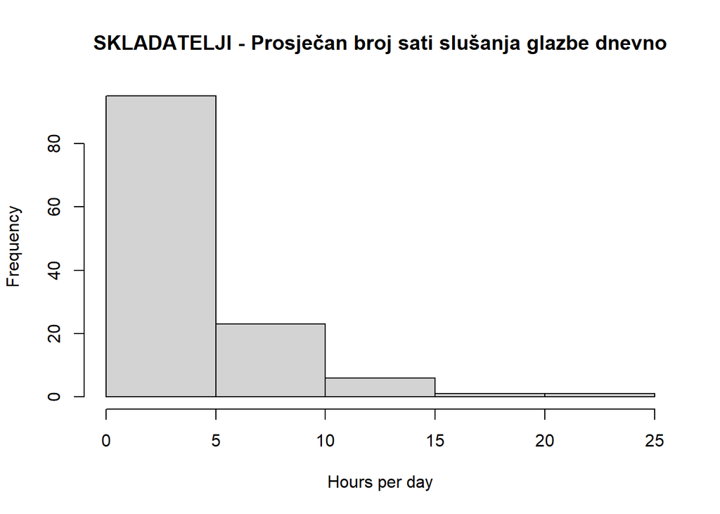

```r
hist(skladatelji$Hours.per.day, main='SKLADATELJI - Prosječan broj sati slušanja glazbe dnevno', xlab='Hours per day', ylab='Frequency')
```

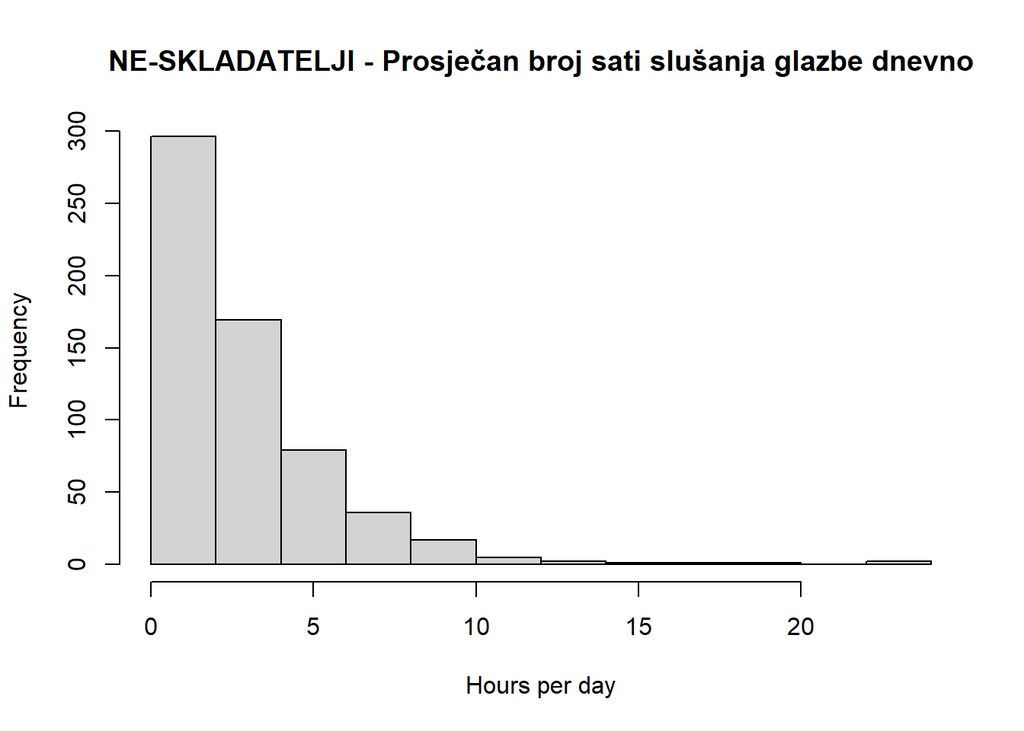

```r
hist(ne_skladatelji$Hours.per.day, main='NE-SKLADATELJI - Prosječan broj sati slušanja glazbe dnevno', xlab='Hours per day', ylab='Frequency')
```

Iz grafova vidimo da uzorci nisu iz normalne distribucije.

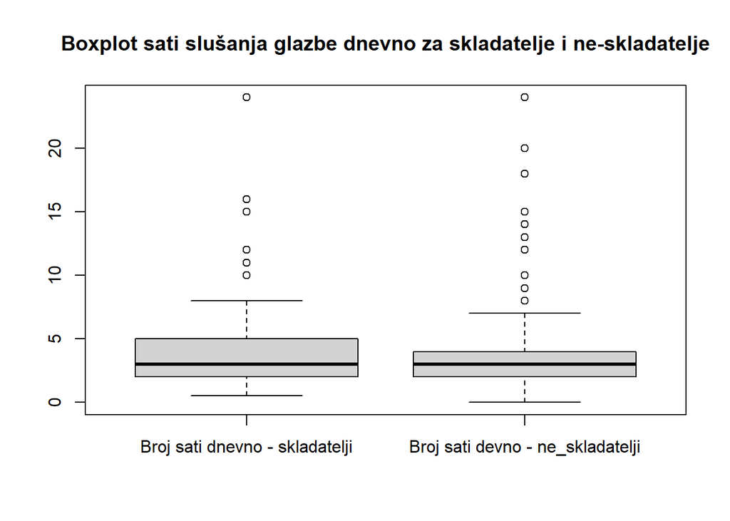

```r
boxplot(skladatelji$Hours.per.day, ne_skladatelji$Hours.per.day,
        names = c('Broj sati dnevno - skladatelji','Broj sati devno - ne_skladatelji'),
        main='Boxplot sati slušanja glazbe dnevno za skladatelje i ne-skladatelje')
```

Budući da su veličine uzorka n1 = 126 (skladatelji), n2 = 609 (ne-skladatelji) možemo koristiti t-test, iako se ne radi o normalnoj distribuciji. T-test je robustan na normalnost, što znači da, čak i ako distribucija nije potpuno normalna, t-test može dati pouzdane rezultate ako je uzorak dovoljno velik (obično n > 30).

Uzorci su nezavisni (skladatelji i ne-skladatelji su različite skupine, izbor jedne osobe iz jedne skupine ne utječe na izbor druge osobe iz druge skupine)

Postavljamo hipoteze:

𝐻0: 𝜇1=𝜇2 (prosječni broj sati slušanja glazbe dnevno za skladatelje i neskladatelje je jednak)

𝐻1: 𝜇1>𝜇2 (skladatelji prosječno slušaju više sati glazbe dnevno od drugih)

Provodimo t-test (pretp. da su varijance razlicite):

```r
t.test(skladatelji$Hours.per.day, ne_skladatelji$Hours.per.day,
                        alternative = "greater", var.equal = FALSE)
```

```
##
##  Welch Two Sample t-test
##
## data:  skladatelji$Hours.per.day and ne_skladatelji$Hours.per.day
## t = 3.1574, df = 159.91, p-value = 0.0009516
## alternative hypothesis: true difference in means is greater than 0
## 95 percent confidence interval:
##  0.5101643       Inf
## sample estimates:
## mean of x mean of y
##  4.464286  3.392529
```

P-vrijednost je vrlo mala (0.0009516), što je manje od tipične razine značajnosti (0.05). Postoji statistički značajna razlika u prosječnom broju sati slušanja glazbe dnevno između skladatelja i ne-skladatelja.

Zaključak: Skladatelji slušaju značajno više glazbe dnevno od drugih.

## ZADATAK 2. - korelacija frekvencije slušanja žanrova i razine mentalnih poremećaja

Istražujemo kolika je korelacija između frekvencija slušanja različitih glazbenih žanrova i samoprocijenjenih razina mentalnih poremećaja. Nadalje, testirat ćemo je li korelacija izmedu frekvencije slušanja metal žanra i samoprocijenjene razine depresije statistički značajna.

Na početku histogramima prikazujemo podatke o frekvenciji slušanja pojedinih glazbenih žanrova.

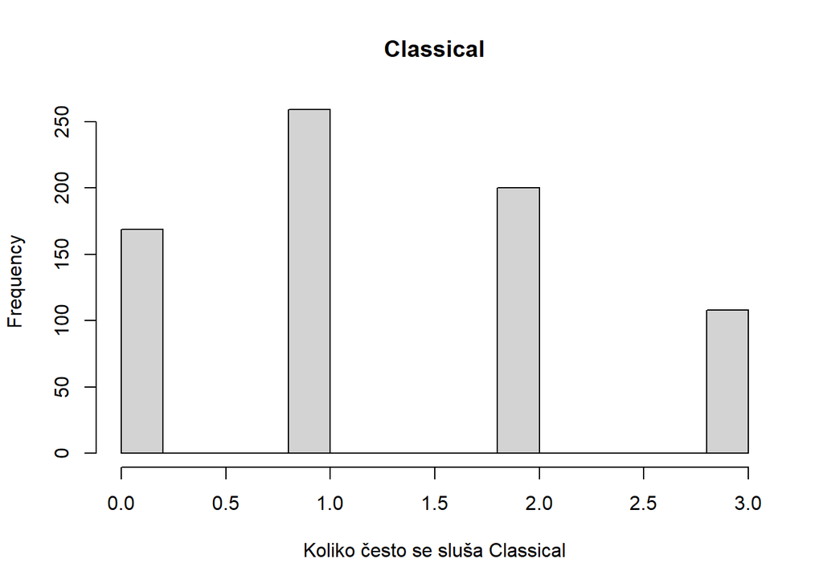

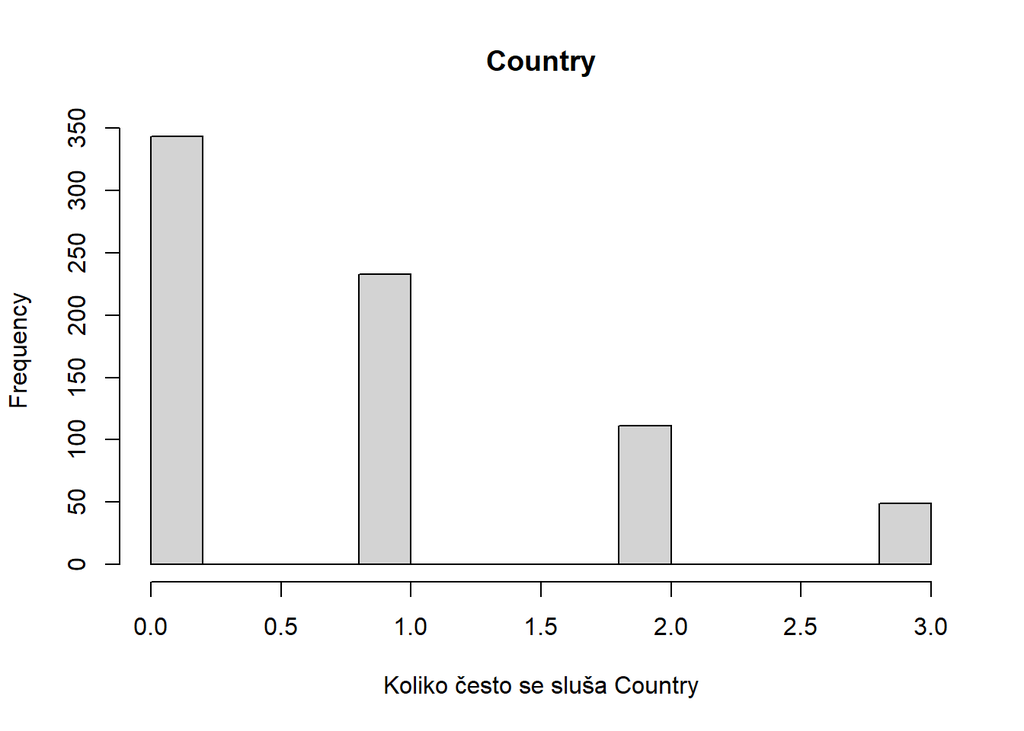

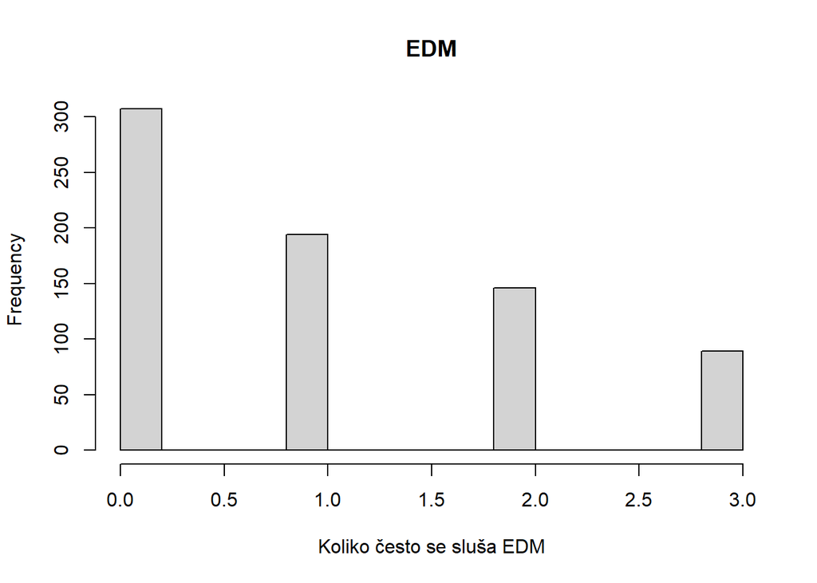

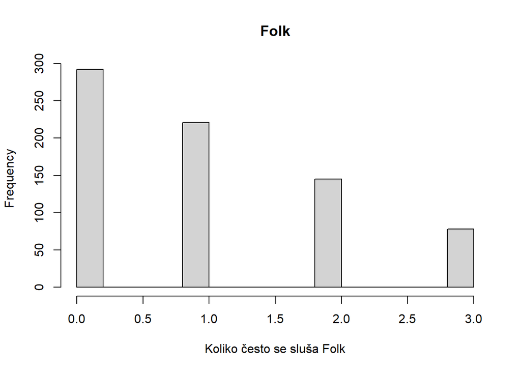

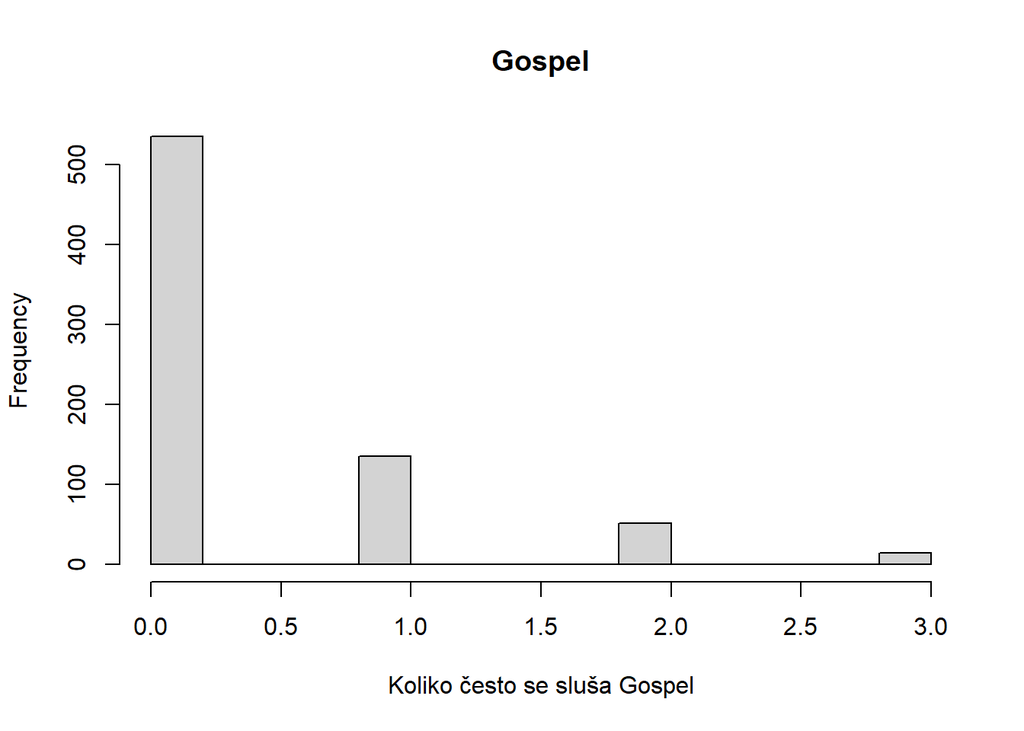

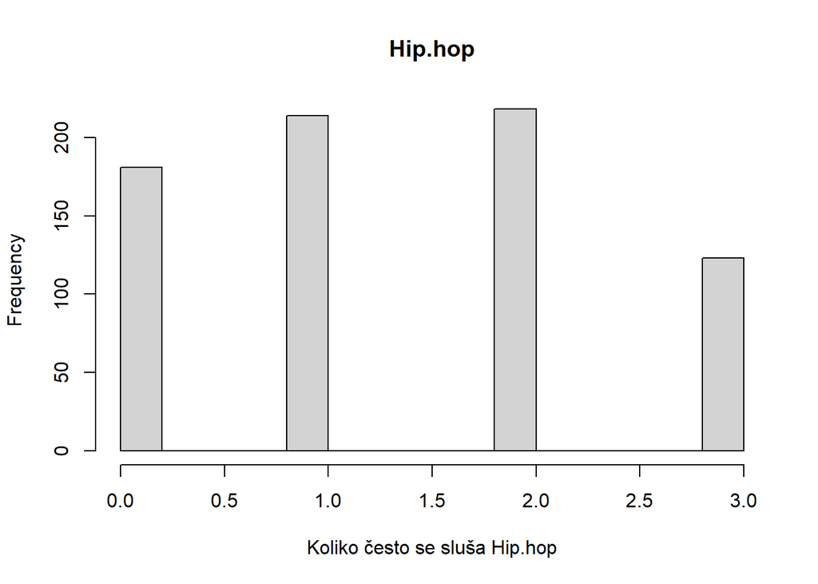

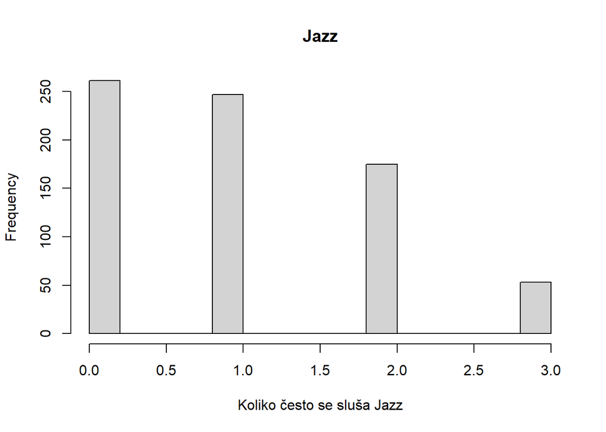

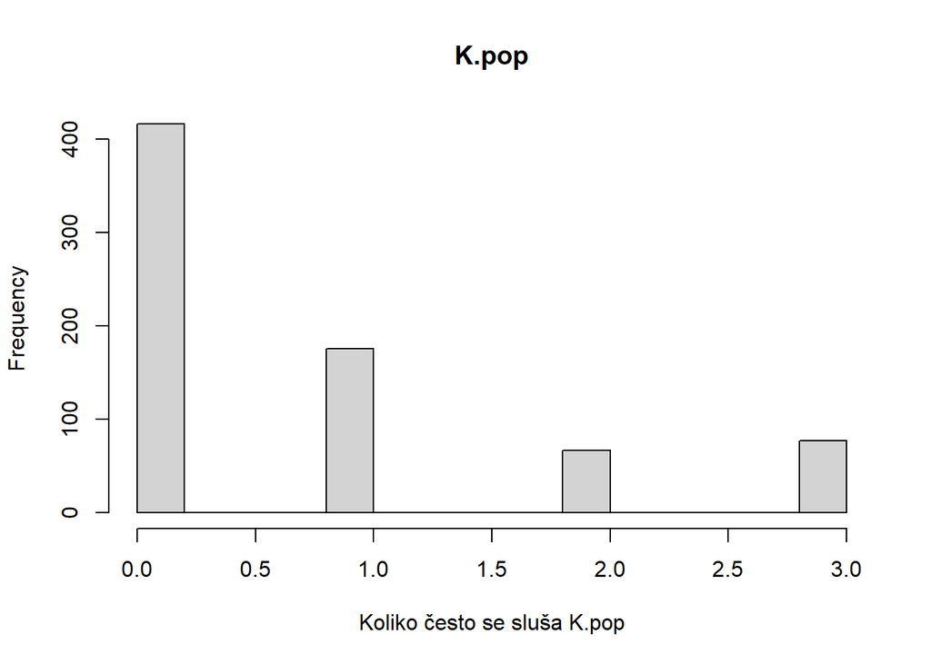

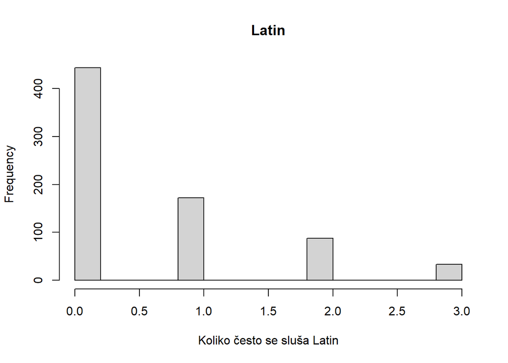

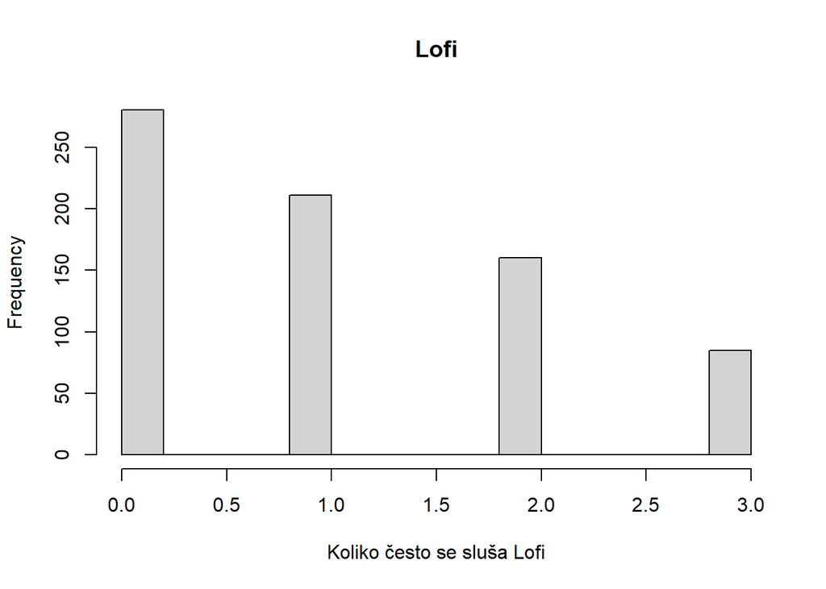

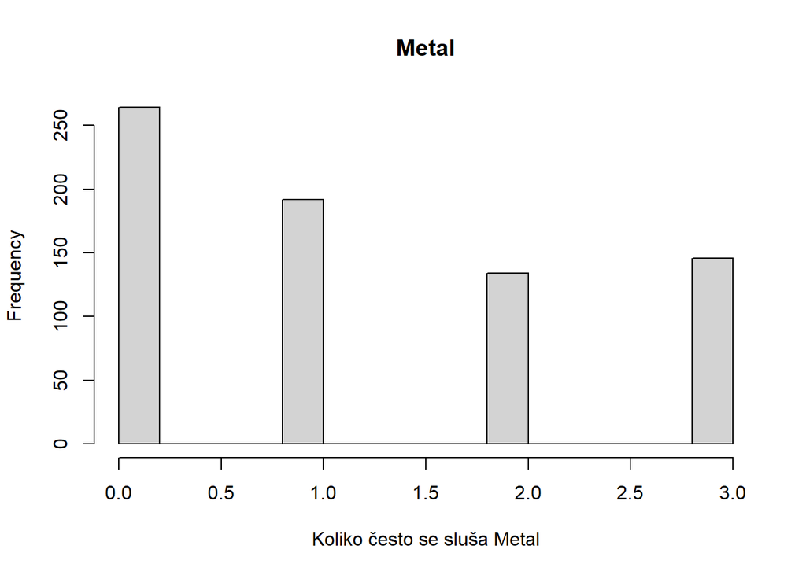

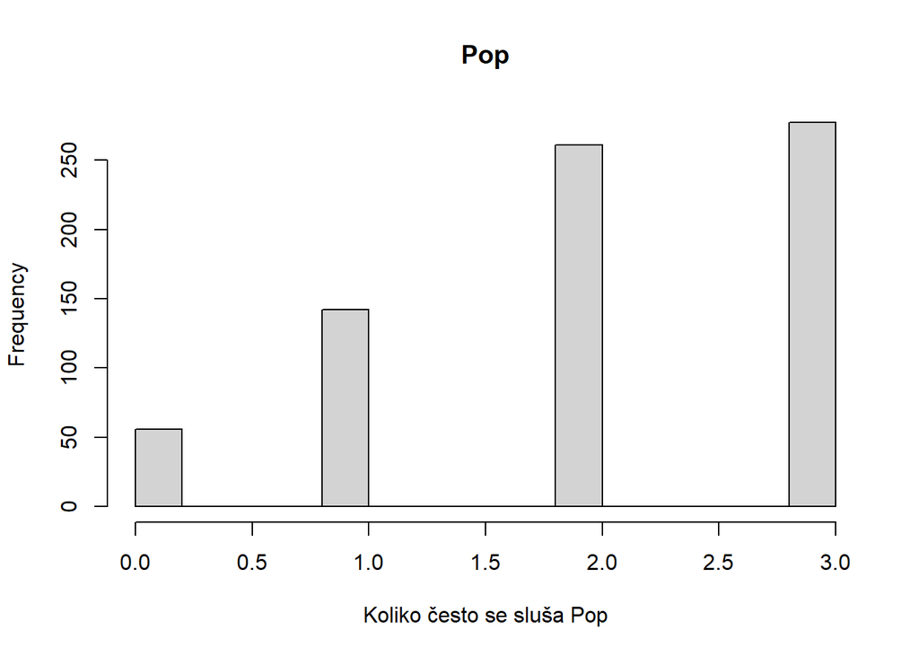

[4 more figures not shown]

```r
# Pretvorba 'Frequency [žanr]' u numeričke vrijednosti
frequency_mapping <- c("Never" = 0, "Rarely" = 1, "Sometimes" = 2, "Very frequently" = 3)

# Popis glazbenih žanrova i mentalnih poremećaja

genres <- c("Classical", "Country", "EDM", "Folk", "Gospel", "Hip.hop",
            "Jazz", "K.pop", "Latin", "Lofi", "Metal", "Pop",
            "R.B", "Rap", "Rock", "Video.game.music")

mental_health <- c("Anxiety", "Depression", "Insomnia", "OCD")

for (genre in genres){
  hist(as.numeric(frequency_mapping[dataset[[paste0("Frequency..", genre, ".")]]]), main = genre, xlab = paste0("Koliko često se sluša ", genre))
}
```

U nastavku histogramima prikazujemo podatke o samoprocijenjenim razinama anksioznosti, depresije, nesanice i OCD-a.

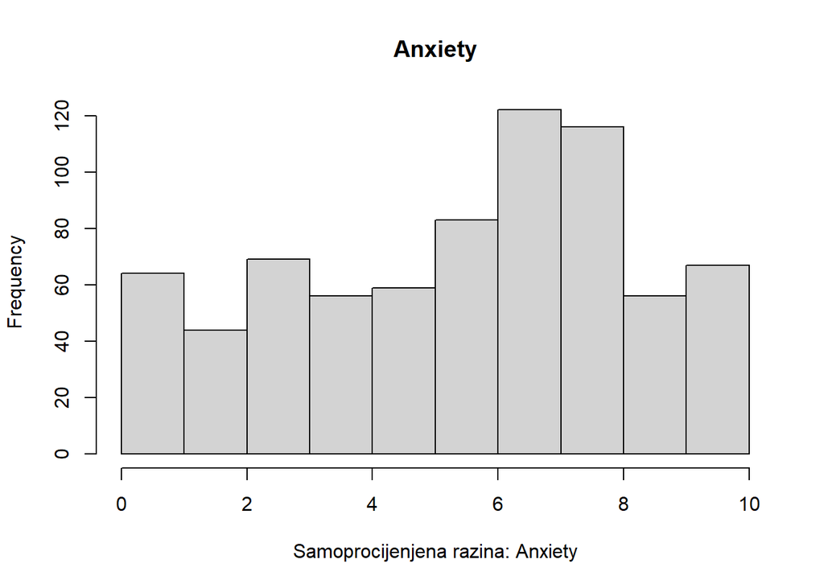

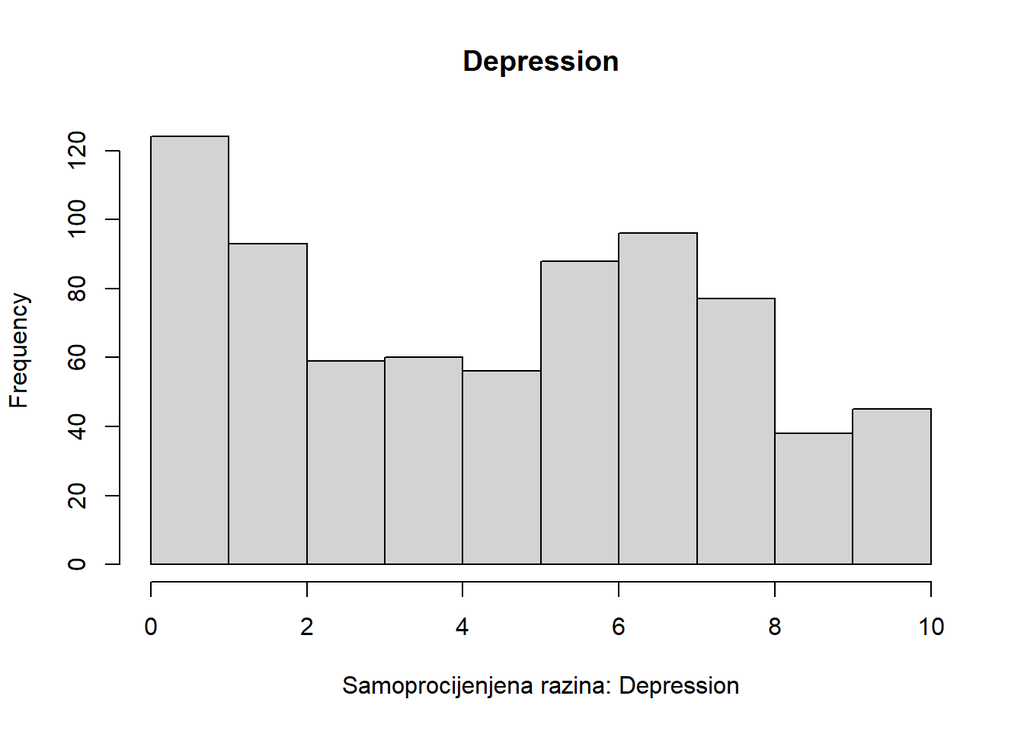

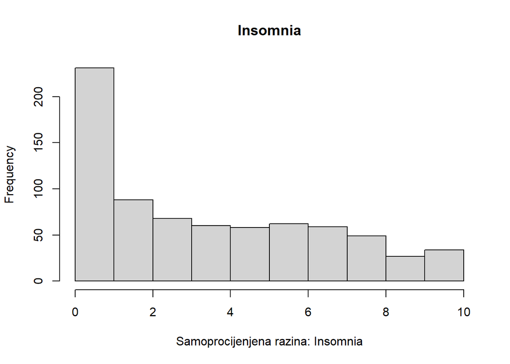

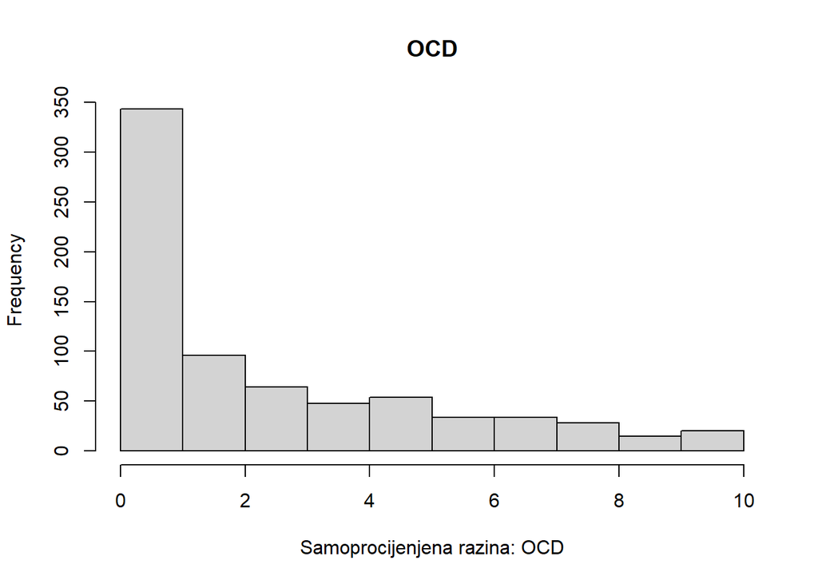

```r
for (poremecaj in mental_health){
  hist(dataset[[paste0(poremecaj)]] ,
       main = poremecaj,
       xlab = paste0("Samoprocijenjena razina: ", poremecaj))
}
```

Iz grafova vidimo da podaci nisu normalno distribuirani, ali s obzirom na to da imamo dovoljno velik uzorak, temeljem centralnog graničnog teorema, koji kaže da će distribucija uzorka težiti normalnoj distribuciji kako se veličina uzorka povećava, možemo kasnije koristiti Pearsonov test.

U sljedećem ispisu možemo vidjeti korelacije između frekvencija slušanja različitih glazbenih žanrova i samoprocijenjenih razina mentalnih poremećaja:

```r
# Pretvorba 'Frequency [žanr]' u numeričke vrijednosti
frequency_mapping <- c("Never" = 0, "Rarely" = 1, "Sometimes" = 2, "Very frequently" = 3)

for (genre in genres) {
  cat("\n", genre, "\n")  # Ispis naziva žanra
  for (mental_var in mental_health) {
    correlation <- cor(
      as.numeric(frequency_mapping[dataset[[paste0("Frequency..", genre, ".")]]]),
      dataset[[mental_var]],
      use = "complete.obs"  # Ignoriranje NA vrijednosti
    )
    cat(mental_var, ":", correlation, "\n")  # Ispis korelacije
  }
}
```

```
##
##  Classical
## Anxiety : -0.04725884
## Depression : -0.008252863
## Insomnia : 0.07647354
## OCD : -0.007940657
##
##  Country
## Anxiety : -0.009375447
## Depression : -0.04348357
## Insomnia : -0.05134913
## OCD : 0.05909631
##
##  EDM
## Anxiety : 0.0428472
## Depression : 0.09077585
## Insomnia : 0.08187066
## OCD : 0.09911854
##
##  Folk
## Anxiety : 0.0921538
## Depression : 0.1127355
## Insomnia : 0.04379328
## OCD : 0.02834439
##
##  Gospel
## Anxiety : -0.03810421
## Depression : -0.01807664
## Insomnia : 0.003450525
## OCD : 0.01258287
##
##  Hip.hop
## Anxiety : 0.02311356
## Depression : 0.09892021
## Insomnia : 0.01858233
## OCD : 0.04509024
##
##  Jazz
## Anxiety : 0.002204361
## Depression : 0.05268214
```

[output cut: 41 more lines]

```
## Depression : 0.1346383
## Insomnia : 0.03933779
## OCD : 0.03957284
##
##  Rock
## Anxiety : 0.08427333
## Depression : 0.1926477
## Insomnia : 0.08393992
## OCD : -0.001451397
##
##  Video.game.music
## Anxiety : 0.1072229
## Depression : 0.09683145
## Insomnia : 0.09233555
## OCD : 0.03004351
```

Koristimo **Pearsonov test** za određivanje statističke značajnosti između frekvencije slušanja metal žanra i samoprocijenjene razine depresije.

Postavljamo hipoteze:

𝐻0: r = 0 (Nema linearne korelacije između frekvencije slušanja metal žanra i samoprocijene razine depresije.)

𝐻1: r != 0 (Postoji linearna korelacija između frekvencije slušanja metal žanra i samoprocijene razine depresije.)

```r
metal_test <- cor.test(as.numeric(frequency_mapping[dataset$Frequency..Metal.]), dataset$Depression)
print(metal_test)
```

```
##
##  Pearson's product-moment correlation
##
## data:  as.numeric(frequency_mapping[dataset$Frequency..Metal.]) and dataset$Depression
## t = 4.8599, df = 734, p-value = 1.437e-06
## alternative hypothesis: true correlation is not equal to 0
## 95 percent confidence interval:
##  0.1056453 0.2456958
## sample estimates:
##       cor
## 0.1765641
```

U rezultatu testa vidimo da je p-vrijednost 1.437e-06 što je vrlo mala vrijednost te nam govori da je korelacija između frekvencije slušanja metal žanra i samoprocijenjene razine depresije statistički značajna na uobičajenoj razini značajnosti p < 0.05.

## ZADATAK 3. - povezanost između korištenog streaming servisa i sklonosti istraživanju

U ovom ćemo zadatku provjeriti postoji li povezanost između korištenog streaming servisa i sklonosti istraživanju.

Za to možemo koristiti Chi-squared test nezavisnosti:

Povezanost između korištenog streaming servisa i sklonosti istraživanju osobe svodi se na test nezavisnosti kategorijskih podataka. U ovom slučaju testiramo nezavisnost stupaca *Primary.streaming.service* i *Exploratory*.

Provodi se na način da se stvori kontingencijska tablica i izračunaju se očekivane vrijednosti. Zatim se računa $\chi^2 = \Sigma_{i,j}\frac{(o_{i,j} - e_{i,j})^2}{e_{i,j}}$ tj. provodi se $\chi^2$ test.

```r
tbl = table(dataset$Primary.streaming.service, dataset$Exploratory)
head(tbl)
```

```
##
##                                      No Yes
##                                       0   1
##   Apple Music                        12  39
##   I do not use a streaming service.  46  25
##   Other streaming service            21  29
##   Pandora                             3   8
##   Spotify                           102 356
```

Potrebno je ukloniti jedan redak jer sadrži vrijednost “” za streaming servis te stvaramo kontingencijsku tablicu za naš primjer.

```r
tbl <- tbl[-1,]
margin_tbl = addmargins(tbl)
print(margin_tbl)
```

```
##
##                                      No Yes Sum
##   Apple Music                        12  39  51
##   I do not use a streaming service.  46  25  71
##   Other streaming service            21  29  50
##   Pandora                             3   8  11
##   Spotify                           102 356 458
##   YouTube Music                      27  67  94
##   Sum                               211 524 735
```

S obzirom da $\chi^2$ test pretpostavlja da je očekivana vrijednost pojedinog razreda veća ili jednaka 5, provjeravamo zadovoljava li naša tablica taj uvjet.

```r
for(col_name in colnames(margin_tbl)){
  for(row_name in rownames(margin_tbl)){
    if(!(row_name=='Sum' | col_name=='Sum')){
      cat("ocekivane vrijednosti za ",col_name,"-",row_name,": ",margin_tbl[row_name,'Sum'] * margin_tbl['Sum',col_name] / margin_tbl['Sum','Sum'], '\n' )
    }
  }
}
```

```
## ocekivane vrijednosti za  No - Apple Music :  14.64082
## ocekivane vrijednosti za  No - I do not use a streaming service. :  20.38231
## ocekivane vrijednosti za  No - Other streaming service :  14.35374
## ocekivane vrijednosti za  No - Pandora :  3.157823
## ocekivane vrijednosti za  No - Spotify :  131.4803
## ocekivane vrijednosti za  No - YouTube Music :  26.98503
## ocekivane vrijednosti za  Yes - Apple Music :  36.35918
## ocekivane vrijednosti za  Yes - I do not use a streaming service. :  50.61769
## ocekivane vrijednosti za  Yes - Other streaming service :  35.64626
## ocekivane vrijednosti za  Yes - Pandora :  7.842177
## ocekivane vrijednosti za  Yes - Spotify :  326.5197
## ocekivane vrijednosti za  Yes - YouTube Music :  67.01497
```

Primjećujemo da je očekivana vrijednost za Pandora-No iznosa manjeg od 5, stoga ne smijemo koristiti $\chi^2$ test već nam je potreban Fisher-Irwingov egzaktni test ( na razini značajnosti 0.05).

Postavljamo hipoteze:

H0: Ne postoji zavisnost između korištenog streaming servisa i sklonosti istraživanju.

H1: Navedena obilježja su zavisna.

```r
fisher.test(tbl, workspace=2e8)
```

```
##
##  Fisher's Exact Test for Count Data
##
## data:  tbl
## p-value = 1.009e-10
## alternative hypothesis: two.sided
```

Dobivena p-vrijednost je znatno manja od postavljane razine značajnosti, stoga možemo odbaciti H0 u korist H1. Odnosno, na razini značajnosti 0.05, možemo tvrditi da postoji povezanost između korištenog streaming servisa i sklonosti istraživanju osobe.

## ZADATAK 4. - razlika prosječnog broja sati slušanja glazbe među korisnicima ovisno o njihovim omiljenim žanrovima

Provjerit ćemo razlikuje li se prosječni broj sati slušanja glazbe značajno među korisnicima ovisno o njihovim omiljenim žanrovima.

Budući da ćemo testirati sredinu više populacija, koristit ćemo ANOVA metodu. Populacije ćemo grupirati po omiljenom žanru i zatim gledati prosječni broj sati.

Pretpostavke ANOVA-e su: - nezavisnost pojedinih podataka u uzorcima, - normalna razdioba podataka, - homogenost varijanci među populacijama.

Nezavisnost podataka je zadovoljena. Već smo zaključili da normalnost nije zadovoljena, međutim ANOVA je robusna na to uz dovoljnu količinu podatka i ako su populacije podjednako velike.

```r
# veličine populacija, koliko ima ljudi s određenim omiljenim žanrom
table(dataset$Fav.genre)
```

```
##
##        Classical          Country              EDM             Folk
##               53               25               37               30
##           Gospel          Hip hop             Jazz            K pop
##                6               35               20               26
##            Latin             Lofi            Metal              Pop
##                3               10               88              114
##              R&B              Rap             Rock Video game music
##               35               22              188               44
```

Iz tablice vidimo da veličine populacija nisu jednake, što sugerira da ANOVA u tom slučaju ne bi bila robusna na nenormalnost i nehomogenost varijanci –> potrebno je ispitati normalnost i homogenost prikladnim testovima.

Provjera homogenosti varijanci među populacijama Bartlettovim testom:

H0: varijance su homogene

H1: barem dvije varijance nisu jednake

```r
# Testiranje homogenosti varijance uzoraka Bartlettovim testom
bartlett.test(dataset$Hours.per.day ~ dataset$Fav.genre)
```

```
##
##  Bartlett test of homogeneity of variances
##
## data:  dataset$Hours.per.day by dataset$Fav.genre
## Bartlett's K-squared = 118.84, df = 15, p-value < 2.2e-16
```

```r
sapply(split(dataset$Hours.per.day, dataset$Fav.genre), var)
```

```
##        Classical          Country              EDM             Folk
##         3.607221         4.993333        16.136637         4.335506
##           Gospel          Hip hop             Jazz            K pop
##         8.043750         8.869748        15.244079        11.280000
##            Latin             Lofi            Metal              Pop
##        22.333333         4.400000         6.096885         4.767990
##              R&B              Rap             Rock Video game music
##         4.219748        41.370130        10.935626         6.447509
```

Odbacujemo nultu hipotezu zbog signifikantne p-vrijednosti (< 2.2e-16) i zaključujemo da varijance nisu homogene.

Provodimo log transformaciju na slušanim satima i ponovno radimo test.

H0: varijance su homogene

H1: barem dvije varijance nisu jednake

```r
log_hours = log(dataset$Hours.per.day + 1)
bartlett.test(log_hours ~ dataset$Fav.genre)
```

```
##
##  Bartlett test of homogeneity of variances
##
## data:  log_hours by dataset$Fav.genre
## Bartlett's K-squared = 18.167, df = 15, p-value = 0.254
```

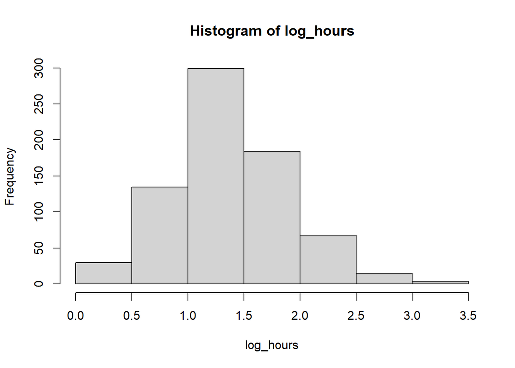

```r
hist(log_hours)
```

Dobili smo p-vrijednost = 0.254. Prema tome, ne odbacujemo H0 i zaključujemo da su varijance sada homogene među populacijama. Korisna nuspojava je da se log transformacijom približimo normalnoj razdiobi podataka, što se vidi na histogramu.

–> zadovoljene su pretpostavke ANOVA-e.

Provodimo ANOVA test:

H0: ne postoje značajne razlike u prosječnom broju sati slušanja glazbe među korisnicima ovisno o njihovim omiljenim žanrovima

H1: postoje značajne razlike (…)

```r
anova = aov(log_hours ~ dataset$Fav.genre, data = dataset)
summary(anova)
```

```
##                    Df Sum Sq Mean Sq F value  Pr(>F)
## dataset$Fav.genre  15  10.51  0.7008   2.339 0.00284 **
## Residuals         720 215.76  0.2997
## ---
## Signif. codes:  0 '***' 0.001 '**' 0.01 '*' 0.05 '.' 0.1 ' ' 1
```

Budući da je p-vrijednost = 0.00284 < 0.05, odbacujemo H0 i zaključujemo da postoje značajne razlike u prosječnom broju sati slušanja glazbe među korisnicima ovisno o njihovim omiljenim žanrovima.

## ZADATAK 5. - Može li se iz zadanih podataka predvidjeti dob ispitanika?

Predviđanje dobi ispitanika temelji se na pretpostavci da se može pronaći linearna veza između dobi i drugih varijabli u skupu podataka. Linearnu vezu između dobi i drugih varijabli dobit ćemo linearnom regresijom.

Svi stupci u našem datasetu:

```r
# Provjera broja NA za svaku varijablu
na_counts <- sapply(dataset, function(x) sum(is.na(x)))

# Ispis rezultata
na_counts[c("Hours.per.day", "BPM", "Anxiety", "Depression", "Insomnia", "OCD",
            "Primary.streaming.service", "Fav.genre", "While.working",
            "Instrumentalist", "Composer", "Exploratory", "Foreign.languages",
            "Frequency..Classical.", "Frequency..Country.", "Frequency..EDM.",
            "Frequency..Folk.", "Frequency..Gospel.", "Frequency..Hip.hop.",
            "Frequency..Jazz.", "Frequency..K.pop.", "Frequency..Latin.",
            "Frequency..Lofi.", "Frequency..Metal.", "Frequency..Pop.",
            "Frequency..R.B.", "Frequency..Rap.", "Frequency..Rock.",
            "Frequency..Video.game.music.", "Music.effects", "BPM", "Age")]
```

```
##                Hours.per.day                          BPM
##                            0                          107
##                      Anxiety                   Depression
##                            0                            0
##                     Insomnia                          OCD
##                            0                            0
##    Primary.streaming.service                    Fav.genre
##                            0                            0
##                While.working              Instrumentalist
##                            0                            0
##                     Composer                  Exploratory
##                            0                            0
##            Foreign.languages        Frequency..Classical.
##                            0                            0
##          Frequency..Country.              Frequency..EDM.
##                            0                            0
##             Frequency..Folk.           Frequency..Gospel.
##                            0                            0
##          Frequency..Hip.hop.             Frequency..Jazz.
##                            0                            0
##            Frequency..K.pop.            Frequency..Latin.
##                            0                            0
##             Frequency..Lofi.            Frequency..Metal.
##                            0                            0
##              Frequency..Pop.              Frequency..R.B.
##                            0                            0
##              Frequency..Rap.             Frequency..Rock.
##                            0                            0
## Frequency..Video.game.music.                Music.effects
##                            0                            0
##                          BPM                          Age
##                          107                            1
```

Iz ispisa uočavamo da postoji čak 107 nedefiniranih odgovora na BPM, što bi moglo stvarati probleme.

Pokušajmo transformirati kontinuirane varijable (hours per day, bpm) i provjeriti ima li naznaka linearnosti:

```r
# Filtriranje skupa podataka da ne uključuje BPM == 999999999 (ekstremna vrijednost)
dataset <- dataset[dataset$BPM != 999999999, ]

sum(is.na(dataset))  # Ukupan broj NA vrijednosti
```

```
## [1] 3531
```

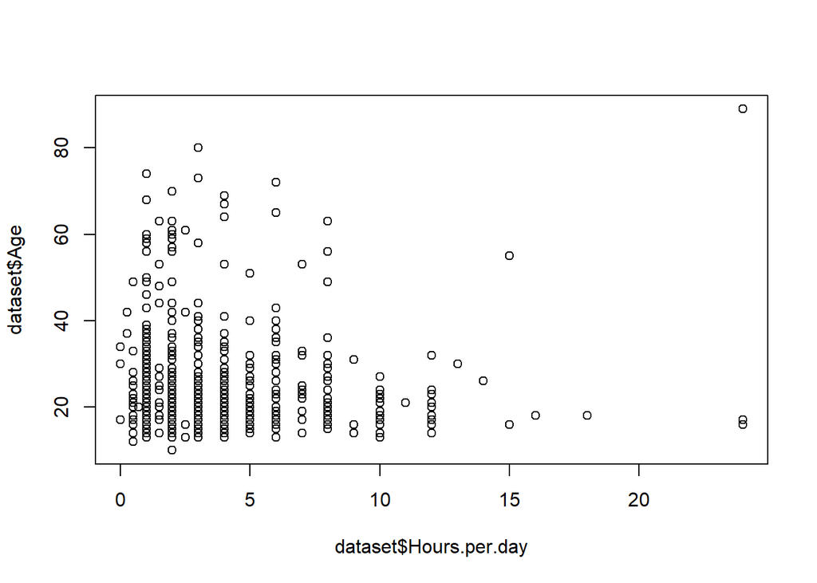

```r
#ispis grafova potencijalnih transformacija da dobijemo linearnost
plot(dataset$Hours.per.day, dataset$Age)
```

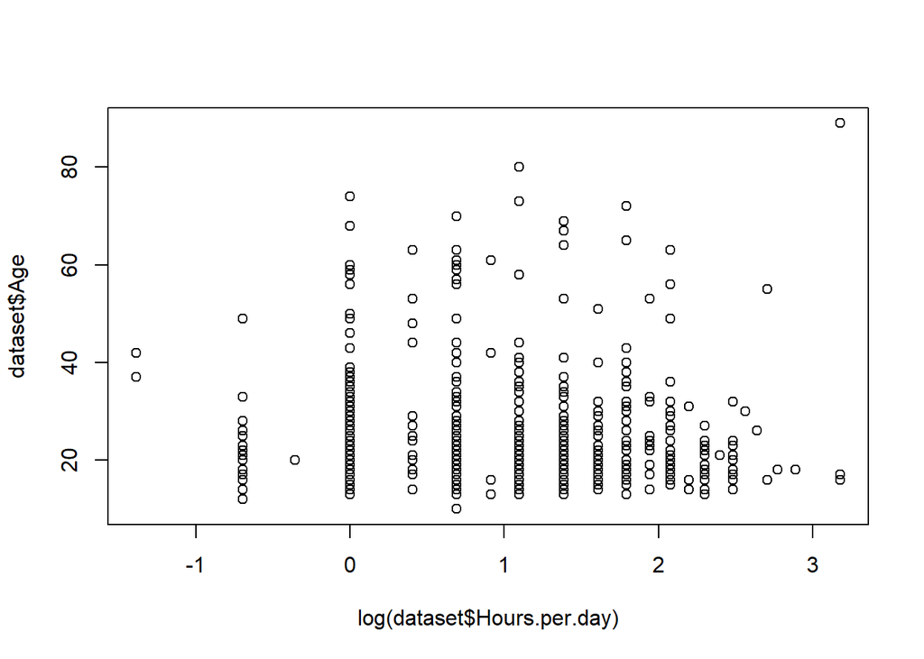

```r
plot(log(dataset$Hours.per.day), dataset$Age)
```